# dtplyr 鬼はええ！ このままdplyrパイプライン 全部data.tableで計算しようぜ！

2022-07-23 第100回R勉強会@東京  
@eitsupi

# はじめに

## 自己紹介

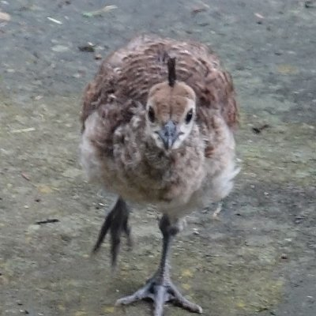

- [@eitsupi](https://twitter.com/eitsupi)
- 製造業勤務
  - Excelが嫌になりRを触り初めて3年
- Dockerイメージ`rocker/r-ver`他のメンテナー

# [前回](https://eitsupi.github.io/tokyorslide/tokyor_97/)のあらすじ

巨大なデータを扱うときにはCSVではなくParquetを使うと便利です。

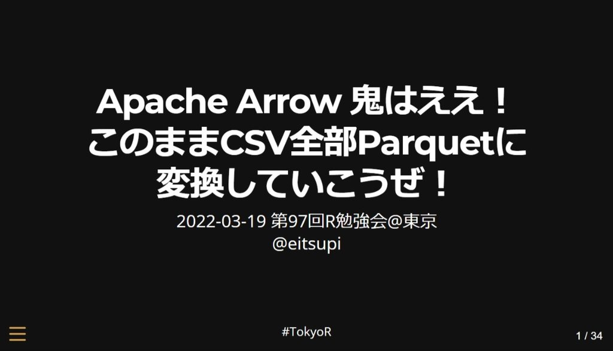

## 今日の話

- `dplyr`バックエンドの速度比較をやってみた。
- `dtplyr`の日本語の情報が少ないので共有したい。
  - [今こそ、data.tableを学ぼう！](https://speakerdeck.com/s_uryu/datatable1130)(2020-08-01)もご確認ください。

### 対象かも

- ✅`dplyr`派
- ✅`dbplyr`や`dtplyr`を試す機会のなかった方

### 対象外かも

- ✅`data.table`派

# 結論

Q. `data.table`って速いの？

A. `dtplyr`ですぐに試せるのでやってみましょう！  
（`tidyverse`パッケージインストール時にインストールされてます！）

# `dtplyr`, `arrow`, `duckdb`

## `dplyr`バックエンド達

`dplyr`で記述したデータ操作を`dplyr`外で実行するパッケージ。

- tydyverse[^1]
  - [`multidplyr`](https://multidplyr.tidyverse.org/) : Rの計算を分散
  - [`dtplyr`](https://dtplyr.tidyverse.org/) : [`data.table`](https://rdatatable.gitlab.io/data.table/)のクエリに変換して計算実行
  - [`dbplyr`](https://dbplyr.tidyverse.org/) : [`duckdb`](https://duckdb.org/docs/api/r)などのDBにSQLを送信して計算実行
- その他
  - [`sparklyr`](https://spark.rstudio.com/) : SparkにSQLを送信して計算実行
  - [`arrow`](https://arrow.apache.org/docs/r/) : Arrow C++ライブラリの計算エンジンAceroで計算実行

## どれが速いか気になる！

- `dtplyr`, `arrow`, `dbplyr`+`duckdb`は同じような目的（ローカル実行で集約計算などを速くしたい）で使用されます。
  - [前回の発表](https://eitsupi.github.io/tokyorslide/tokyor_97/)で`arrow`と共に`duckdb`を紹介したところ、  
    「`duckdb`の使いどころが分からない」との感想をいただいた。
- 有名な[H2Oベンチマーク](https://h2oai.github.io/db-benchmark/)は最後の実行が2021年7月、 まだ`arrow`は`dplyr::summarise`を実行できなかった頃の結果。

# ベンチマーク

## 対象パッケージ

```r
library(dplyr)
library(dtplyr)
library(arrow)
library(duckdb)
```

これらで、以下のようなグループ毎の集約計算を行います。

```r
mtcars |>
  dplyr::group_by(cyl) |>
  dplyr::summarise(sum = sum(wt, na.rm = TRUE), .groups = "drop")
```

```
# A tibble: 3 × 2
    cyl   sum
  <dbl> <dbl>
1     4  25.1
2     6  21.8
3     8  56.0
```

## 準備 1/3

行数、列数、グループ数を変えてベンチマークするために、  
データフレームを以下のような関数で作れるようにしておきます。

```r
.gen_data <- \(n_group, n_row, n_col_value, .seed = 1) {
  groups <- seq_len(n_group) |>
    rep_len(n_row) |>
    as.character()

  set.seed(.seed)

  runif(n_row * n_col_value, min = 0, max = 100) |>
    round() |>
    matrix(ncol = n_col_value) |>
    tibble::as_tibble(
      .name_repair = \(x) paste0("col_value_", seq_len(n_col_value))
    ) |>
    dplyr::mutate(col_group = groups, .before = 1)
}
```

## 準備 2/3

各パッケージによる計算も関数化しておきます。

### dplyr

```r
.use_dplyr <-
  function(.data, .fn = dplyr::summarise) {
  .data |>
    dplyr::group_by(col_group) |>
    .fn(
      value = sum(col_value_1, na.rm = TRUE),
    )
  }
```

### dtplyr

```r
.use_dtplyr <-
  function(.data, .fn = dplyr::summarise) {
  .data |>
    dtplyr::lazy_dt() |>
    dplyr::group_by(col_group) |>
    .fn(
      value = sum(col_value_1, na.rm = TRUE),
    ) |>
    dplyr::collect()
  }
```

二つの関数が同じ結果を返すことを確認します。

```r
df <- .gen_data(3, 300, 10)
dplyr::all_equal(.use_dtplyr(df), .use_dplyr(df))
```

```
[1] TRUE
```

## 準備 3/3

各パッケージによる計算も関数化しておきます。

### arrow

```r
.use_arrow <-
  function(.data, .fn = dplyr::summarise) {
  .data |>
    arrow::arrow_table() |>
    dplyr::group_by(col_group) |>
    .fn(
      value = sum(col_value_1, na.rm = TRUE),
    ) |>
    dplyr::collect()
  }
```

### duckdb

```r
.use_duckdb <-
  function(.data, .fn = dplyr::summarise) {
  .data |>
    arrow::to_duckdb() |>
    dplyr::group_by(col_group) |>
    .fn(
      value = sum(col_value_1, na.rm = TRUE),
    ) |>
    dplyr::collect()
  }
```

```r
dplyr::all_equal(.use_arrow(df), .use_dplyr(df))
```

```
[1] TRUE
```

```r
dplyr::all_equal(.use_duckdb(df), .use_dplyr(df))
```

```
[1] TRUE
```

## ベンチマーク (`summarise`)

行数3条件、グループ数3条件の組み合わせ全9条件で、  
[`bench`](https://bench.r-lib.org/)パッケージによるベンチマークを取ります。

```r
res_sum <- bench::press(
  fn = c("dplyr::summarise"),
  n_row = c(1e6, 1e7, 1e8),
  n_col_value = c(1),
  n_group = c(1e2, 1e3, 1e4),
  {
    dat <- .gen_data(n_group, n_row, n_col_value)
    fn <- eval(parse(text = fn))
    bench::mark(
      check = dplyr::all_equal,
      min_iterations = 5,
      dplyr = .use_dplyr(dat, fn),
      dtplyr = .use_dtplyr(dat, fn),
      arrow = .use_arrow(dat, fn),
      duckdb = .use_duckdb(dat, fn)
    )
  }
)
```

## ベンチマーク結果 (`summarise`)

```r
res_sum |> ggplot2::autoplot("violin")
```

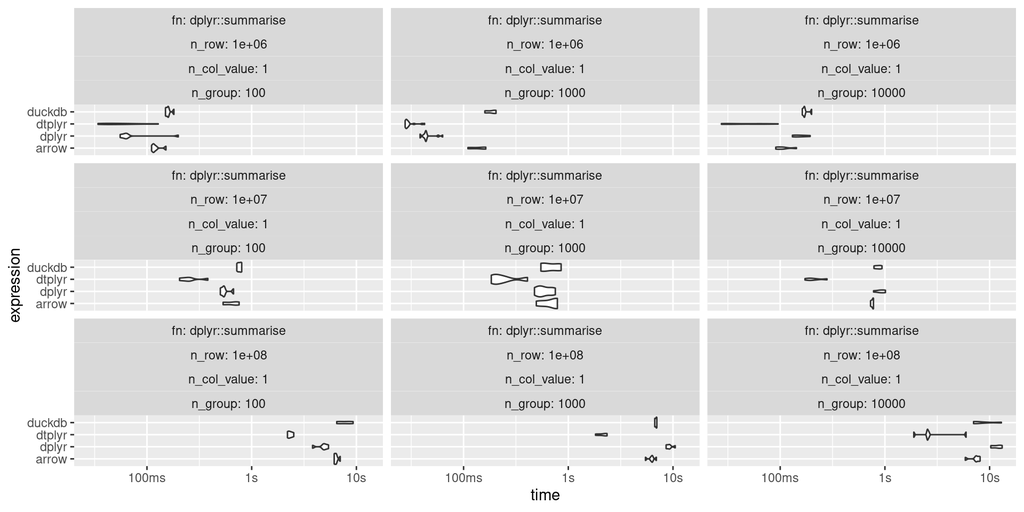

`dtplyr`速い！

## ベンチマーク結果 (`mutate`)

`arrow`はgroupに対する`mutate`非対応、  
`duckdb`の`group`に対する`mutate`は現状とても遅くベンチマークが終わらなかったので省略。

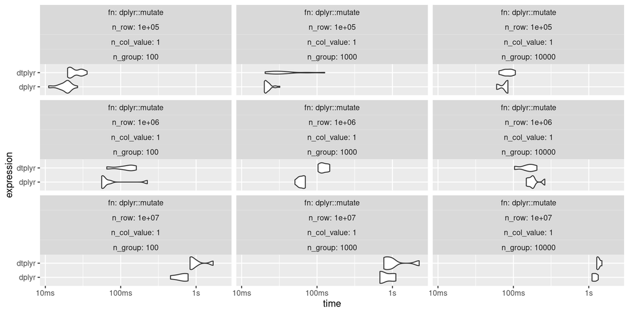

`dplyr`と`dtplyr`ほぼ互角。

## ベンチマーク (`summarise` + `across`)

以下のような、`across`で複数列を対象にする集約計算について、  
列数を変えながらベンチマークを取ってみましょう。

```r
.use_across_dplyr <-
  function(.data, .fn = dplyr::summarise) {
  .data |>
    dplyr::group_by(col_group) |>
    .fn(
      dplyr::across(
        tidyselect::starts_with("col_value"),
        .fns = ~ sum(.x, na.rm = TRUE)
      )
    )
  }
```

`arrow`は現状`across`未対応なので使えません。

## ベンチマーク結果 (`summarise` + `across`)

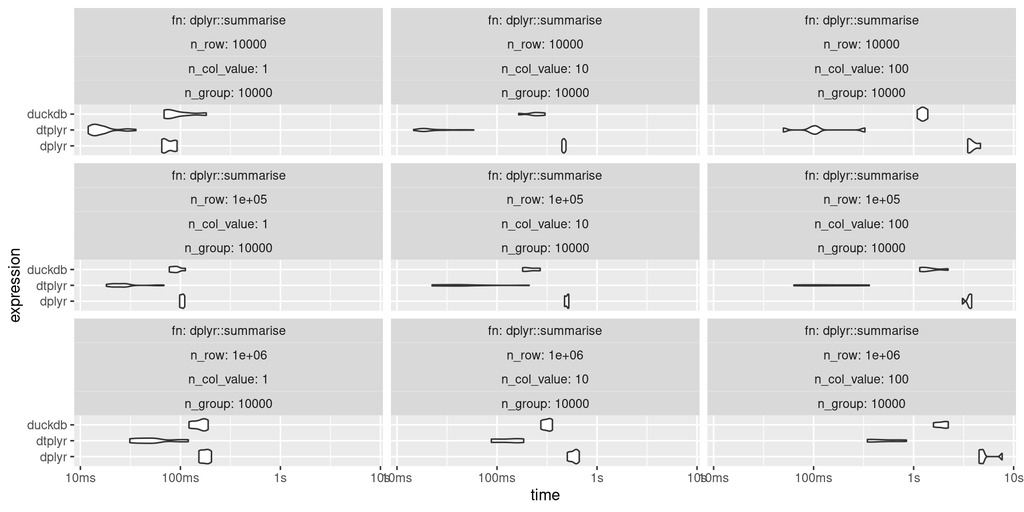

更に行数を増やすと`duckdb`が最速になりそうに見えますが、私のマシン（RAM16GB割り当て）ではこれ以上のサイズでの実行を完了できず……。

## その他

まとめきれなかったもののベンチマーク色々回してて気付いた結果。

- `dtplyr`の`dplyr::summarise()`は列（計算対象外）が増えるだけで遅くなる事象を確認しました。不要な列はあらかじめ`dplyr::select()`で削除する方が良いかも知れません。
- `tidyr::pivot_longer()`は`dplyr`が速かったです。
- ↓みたいなこともできるので組み合わせて使いましょう！

  ```r
  mtcars |>
    arrow::arrow_table() |>
    arrow::to_duckdb() |>
    dtplyr::lazy_dt()
  ```

  - 資料作成中`arrow::Table`を`dtplyr::lazy_dt()`に渡せないバグを見つけたので修正しました。

# まとめ

- `data.table`はマジで速い！
- `dtplyr`で敷居も低い！

**Enjoy!**

#TokyoR

## 脚注

[^1]: [dplyr backends: multidplyr 0.1.0, dtplyr 1.1.0, dbplyr 2.1.0](https://www.tidyverse.org/blog/2021/02/dplyr-backends/)